# An Introduction to celda

### 4.3 LDA Clustering on Cells and Genes

K = Total number of cell populations L = Total number of transcriptional states

```r
celda_cluster_assignments = celda_CG(counts, sample.label = sim_counts$sample,
                                     K = 3, L = 10, max.iter = 25)
```

```
## Thu Mar 30 19:01:36 2017 ... Starting Gibbs sampling
## Thu Mar 30 19:01:37 2017 ... Completed iteration: 1 | logLik: -12590647
## Thu Mar 30 19:01:38 2017 ... Completed iteration: 2 | logLik: -12418613
## Thu Mar 30 19:01:39 2017 ... Completed iteration: 3 | logLik: -12418592
## Thu Mar 30 19:01:39 2017 ... Completed iteration: 4 | logLik: -12418592
## Thu Mar 30 19:01:40 2017 ... Completed iteration: 5 | logLik: -12418602
## Thu Mar 30 19:01:41 2017 ... Completed iteration: 6 | logLik: -12418598
## Thu Mar 30 19:01:42 2017 ... Completed iteration: 7 | logLik: -12418596
## Thu Mar 30 19:01:43 2017 ... Completed iteration: 8 | logLik: -12418593
## Thu Mar 30 19:01:43 2017 ... Completed iteration: 9 | logLik: -12418600
## Thu Mar 30 19:01:44 2017 ... Completed iteration: 10 | logLik: -12418597
## Thu Mar 30 19:01:45 2017 ... Completed iteration: 11 | logLik: -12418595
## Thu Mar 30 19:01:46 2017 ... Completed iteration: 12 | logLik: -12418596
## Thu Mar 30 19:01:47 2017 ... Completed iteration: 13 | logLik: -12418592
## Thu Mar 30 19:01:48 2017 ... Completed iteration: 14 | logLik: -12418594
## Thu Mar 30 19:01:48 2017 ... Completed iteration: 15 | logLik: -12418592
## Thu Mar 30 19:01:49 2017 ... Completed iteration: 16 | logLik: -12418595
## Thu Mar 30 19:01:50 2017 ... Completed iteration: 17 | logLik: -12418594
## Thu Mar 30 19:01:51 2017 ... Completed iteration: 18 | logLik: -12418595
## Thu Mar 30 19:01:51 2017 ... Completed iteration: 19 | logLik: -12418593
## Thu Mar 30 19:01:52 2017 ... Completed iteration: 20 | logLik: -12418594
## Thu Mar 30 19:01:53 2017 ... Completed iteration: 21 | logLik: -12418592
## Thu Mar 30 19:01:53 2017 ... Completed iteration: 22 | logLik: -12418596
## Thu Mar 30 19:01:54 2017 ... Completed iteration: 23 | logLik: -12418595
## Thu Mar 30 19:01:55 2017 ... Completed iteration: 24 | logLik: -12418597
## Thu Mar 30 19:01:56 2017 ... Completed iteration: 25 | logLik: -12418595
```

```r
str(celda_cluster_assignments)
```

```
## List of 12
##  $ z                   : int [1:777] 2 2 2 2 3 3 3 3 3 3 ...
##  $ y                   : int [1:745] 4 7 4 2 2 2 4 5 4 7 ...
##  $ complete.z          : int [1:777, 1:26] 3 3 3 3 2 1 1 2 3 3 ...
##   ..- attr(*, "dimnames")=List of 2
##   .. ..$ : NULL
##   .. ..$ : chr [1:26] "z.all" "z" "z" "z" ...
##  $ complete.y          : int [1:745, 1:26] 1 4 9 8 4 7 7 6 9 4 ...
##   ..- attr(*, "dimnames")=List of 2
##   .. ..$ : NULL
##   .. ..$ : chr [1:26] "y.all" "y" "y" "y" ...
##  $ z.stability         : num 1
##  $ y.stability         : num 0.997
##  $ complete.z.stability: num [1:26] NA 0.832 1 1 1 ...
##  $ complete.y.stability: num [1:26] NA 0.995 0.998 0.997 0.997 ...
##  $ completeLogLik      : num [1:26] -12842655 -12590647 -12418613 -12418592 -12418592 ...
##  $ finalLogLik         : num -12418592
##  $ z.prob              : num [1:777, 1:3] 0 0 0 0 0 0 0 0 0 0 ...
##  $ y.prob              : num [1:745, 1:10] 0.00 8.17e-136 0.00 0.00 0.00 ...
```

complete.z.stability: History of z.stability over all iterations of Gibbs sampling

complete.y.stability: Historyof y.stability over all iterations of Gibbs sampling

completeLogLik: Log-likelihood of all gene and cell cluster assignments over all iterations of Gibbs sampling

finalLogLik: Log-likelihood of final gene and cell cluster assignments

### 4.4 Visualization

#### 4.4.1 Heatmap on Raw data

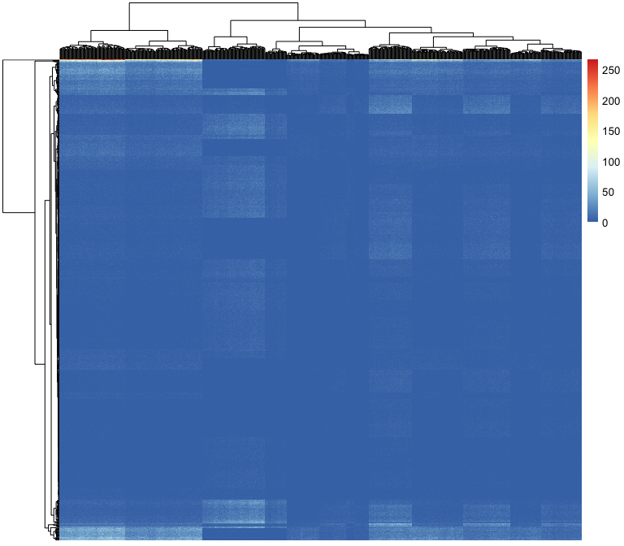

```r
pheatmap(counts)
```

We can see that it is hard for us to extract useful patterns.